# If you can’t beat ’em, JOIN ’em!

Lab

Directions: Follow along with the slides and answer the questions in red font in your journal.

# Overview

- Previously, you learned how to use merge to **join** data sets horizontally. This is where we take one data set’s columns and add them to the end of the other data set’s columns based on matching an **ID** variable. colors and timeuse were merged using user.id as an ID.
- In this lab, we will learn some alternative ways to join two datasets. These are **inner joins**, **outer joins**, **left and right joins**, and **anti joins**. Before diving in, let’s get to know our example datasets.
- Type the following commands into your console:

```r
data(purchases)
```

```r
?purchases
```

```r
data(surveys)
```

```r
?surveys
```

- Do purchases and surveys have the same number of observations?
- What variables do purchases and surveys have in common? What variables are not shared by purchases and surveys?

# Motivation

- Notice that both purchases and surveys contain the variable customer_id - this will be the ID on which we join purchases and surveys.
- Previously, colors and timeuse had the same number of observations. Moreover, the values for user.id were exactly the same in colors and timeuse.
- In contrast, purchases and surveys contain different amounts of observations. Moreover, some values of customer_id occur in both purchases and surveys, some occur only in purchases, and some occur only in surveys. We can express this relationship using a **Venn diagram**.

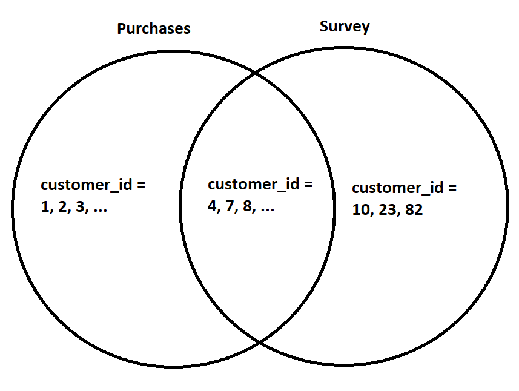

- The positions of datasets on a Venn diagram allow us to designate one dataset as the **left dataset** and the other as the **right dataset**. In this case, purchases is the left dataset and surveys is the right dataset.
- Run the following code:

```r
merge(purchases, surveys, by = "customer_id")
```

- Which values of customer_id are present in the resulting dataset? Do these observations correspond to a section from the Venn diagram?

# Inner joins

- The first way to join two datasets is an **inner join**, which includes a observation when its ID is present in the left **AND** right datasets. In our example, this would be the set of people that made a purchase at the store **AND** filled out the survey. This is illustrated in the Venn diagram:

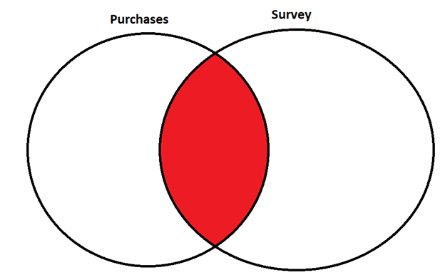

- Notice that this is exactly the behavior of merge. This means that merge carries out an inner join! In fact, the following code produces the exact same output as the code from the previous slide.

```r
inner_join(purchases, surveys, by = "customer_id")
```

- Inner join purchases and surveys and assign the output to inner_customers.
- Does inner_customers have more or fewer observations than purchases? What about surveys?
- What are the variables of inner_customers?
- Is there a relationship between age and average_amount_spent?

# Outer joins

- A second way to join two datasets is an **outer join**, which includes a observation when its ID is present in the left **OR** right datasets. In our example, this would be the set of people that made a purchase at the store **OR** filled out the survey. This is illustrated in the Venn diagram:

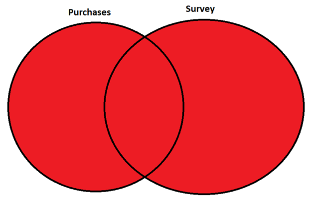

- The syntax for all the join functions is the same as merge:

```r
merge(____, ____, by = "____")
```

- where “merge” is replaced with the specific join function you’d like to use. The join function corresponding to outer join is full_join.
- With this in mind, create an outer join of purchases and surveys, and assign it to outer_customers.
- How many observations and variables does outer_customers have compared to inner_customers?
- You might have noticed that outer_customers contains NA values, but inner_customers does not. Why does this happen? (Hint: what happens when a value of customer_id occurs in purchases, but not surveys, or vice versa?)

# Left and right joins

- Two more kinds of joins are left_join and right_join. As the names suggest, **left joins** keep all the observations in the left dataset, and **right joins** keep all the observations in the right dataset. See the Venn diagrams below:

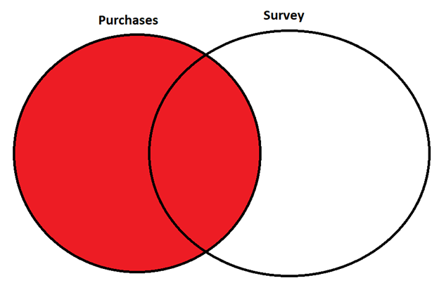

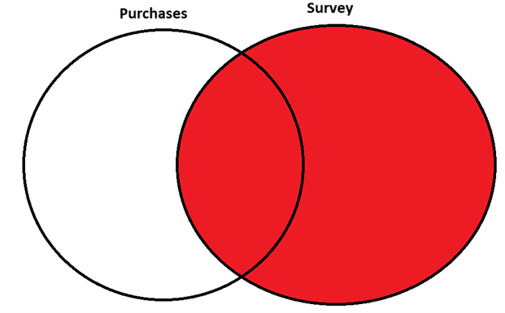

# Anti joins

- The last join function is anti_join. **Anti joins** are a bit unlike the other join functions - rather than adding observations to the left dataset, anti_join **filters** observations from the left dataset. Anti joins keep all the observations of the left dataset that do not have matches in the right dataset. This is illustrated in the Venn diagram:

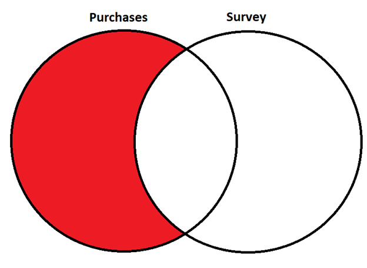

- Create a dataset called anti_survey including customers that made a purchase, but did not fill out the survey.
- Produce a box-and-whisker plot for average_amount_spent amongst customers that made a purchase, but did not fill out the survey.
- How does average_amount_spent for customers that made a purchase but did not fill out the survey compare to average_amount_spent for customers that made a purchase **AND** filled out the survey? How do you interpret the difference?
- (Hint: make another box-and-whisker plot, but using inner_customers.)